# Exploring Preston and Gilthorpe’s adversarial example

Author

@Andi@tech.lgbt

Published

August 26, 2023

```r
library(tidyverse)
library(magrittr)
library(car)
library(MatchIt)
library(WeightIt)
library(marginaleffects)
library(GGally)
library(cobalt)
library(mgcv)
library(quantreg)
library(bestNormalize)
```

Poking around the solution for *Using optimisation methods to generate adversarial datasets for propensity score methods with large post-adjustment bias*, available [yonder](https://osf.io/d279k/).

### Setup

First, get the data. The following code is hiked out of the Rmd provided by the authors.

```r
N <- 2 * 100

partition <- function(xs, k) {
  n <- length(xs)
  split(xs, rep(1:ceiling(n / k), each = k)[1:n])
}

unvectorise_data <- function(v, confounders) {
  data_length <- N * confounders
  intercept_length <- 1
  coeffs_length <- confounders
  residuals_length <- N

  data_v <- v[seq(1, data_length)]
  data_series <- partition(data_v, N)
  names(data_series) %<>% lapply(partial(paste0, "C")) |> unlist()
  data <- as_tibble(data_series)

  data %<>% mutate(X = c(rep(0, N / 2), rep(1, N / 2)))

  intercept <- v[data_length + 1]
  coeffs <- v[seq(data_length + intercept_length + 1,
                  data_length + intercept_length + coeffs_length)]
  residuals <- v[seq(
    data_length + intercept_length + coeffs_length + 1,
    data_length + intercept_length + coeffs_length + residuals_length
  )]
  list(
    data = data,
    intercept = intercept,
    coeffs = coeffs,
    residuals = residuals
  )
}

solution <- read.table("solution.csv",
                       header = TRUE,
                       row.names = 1) |>
  as.matrix() |>
  unvectorise_data(2)
```

Next, set the outcome variable:

```r
set_Y <- function(data, intercept, coeffs, residuals) {
  coeffs_dot <- data |>
    select(starts_with("C")) %>%
    `*`(matrix(
      coeffs,
      nrow = N,
      ncol = length(coeffs),
      byrow = TRUE
    )) |>
    transmute(dot = rowSums(across(.cols = everything()))) |>
    as.list() %>%
    `$`("dot")

  data |>
    mutate(Y = X + coeffs_dot + intercept + residuals)
}

dat <- with(solution,
            set_Y(data, intercept, coeffs, residuals))
```

### Explore

Take a peek:

```r
dat
```

```
# A tibble: 200 × 4
      C1    C2     X        Y
   <dbl> <dbl> <dbl>    <dbl>
 1 0.452 0.531     0 -0.00633
 2 0.491 0.601     0  0.606
 3 0.552 0.198     0 -0.358
 4 0.337 0.498     0  0.407
 5 0.588 0.427     0 -0.190
 6 0.474 0.285     0 -0.518
 7 0.460 0.801     0  0.289
 8 0.386 0.579     0  0.467
 9 0.615 0.563     0  0.544
10 0.499 0.661     0  0.231
# ℹ 190 more rows
```

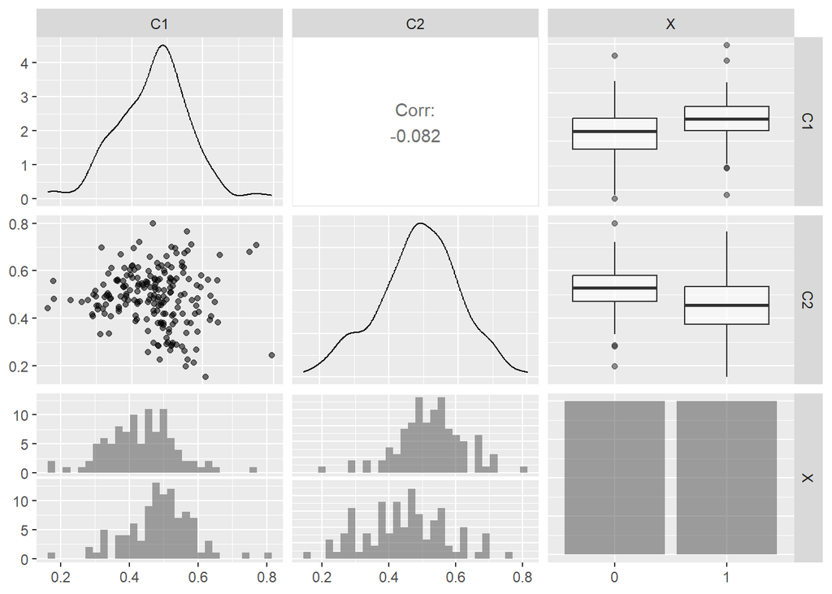

```r
ggpairs(dat |> mutate(X = as.factor(X)), columns = c("C1", "C2", "X"),
        aes(alpha = .5))
```

Let’s see how the covariates relate to the outcome, conditional on *X*:

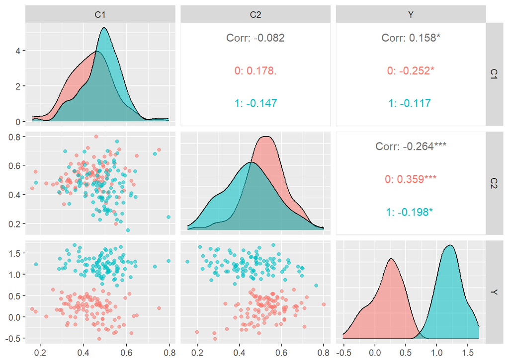

```r
ggpairs(dat, columns = c("C1", "C2", "Y"),
        aes(colour = factor(X),
            alpha = .5))
```

Try to deal with interaction:

```r
mod <- lm(Y ~ X * (C1 + C2), data = mutate(dat, X = as.factor(X)))
```

```r
summary(mod)
```

```
Call:
lm(formula = Y ~ X * (C1 + C2), data = mutate(dat, X = as.factor(X)))

Residuals:
     Min       1Q   Median       3Q      Max
-0.50406 -0.14900 -0.00191  0.16678  0.47412

Coefficients:
            Estimate Std. Error t value Pr(>|t|)
(Intercept) -0.03332    0.13889  -0.240 0.810659
X1           1.56303    0.20319   7.692 7.10e-13 ***
C1          -0.84630    0.21845  -3.874 0.000146 ***
C2           1.10799    0.22369   4.953 1.58e-06 ***
X1:C1        0.52647    0.31887   1.651 0.100344
X1:C2       -1.46371    0.28404  -5.153 6.28e-07 ***
---
Signif. codes:  0 '***' 0.001 '**' 0.01 '*' 0.05 '.' 0.1 ' ' 1

Residual standard error: 0.2155 on 194 degrees of freedom
Multiple R-squared:  0.8599,    Adjusted R-squared:  0.8563
F-statistic: 238.2 on 5 and 194 DF,  p-value: < 2.2e-16
```

So we probably can’t ignore it…

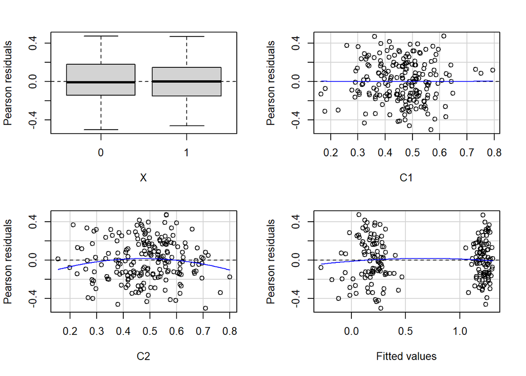

```
           Test stat Pr(>|Test stat|)
X
C1            0.0330         0.973692
C2           -1.5733         0.117290
Tukey test   -2.6908         0.007129 **
---
Signif. codes:  0 '***' 0.001 '**' 0.01 '*' 0.05 '.' 0.1 ' ' 1
```

```r
residualPlots(mod)
```

There’s a quadratic (maybe) relationship between *C2* and residuals.

## Coarsened exact matching

Let’s try CEM, ignoring this, and without covariate adjustment in the outcome model.

```r
match_cem <- matchit(X  ~ C1 + C2,
                     method = "cem",
                     data = dat,
                     estimand = "ATT")
match_cem_dat <- match.data(match_cem)
```

```r
match_cem
```

```
A matchit object
 - method: Coarsened exact matching
 - number of obs.: 200 (original), 190 (matched)
 - target estimand: ATT
 - covariates: C1, C2
```

First look at the ASMD:

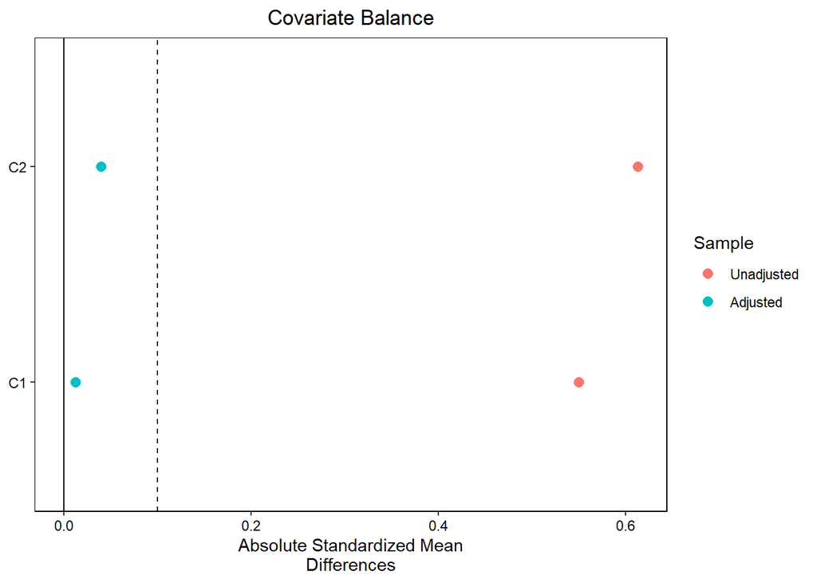

```r
love.plot(match_cem,
          drop.distance = TRUE,
          var.order = "unadjusted",
          abs = TRUE,
          thresholds = c(m = .1))
```

Matching improved balance.

Density plots:

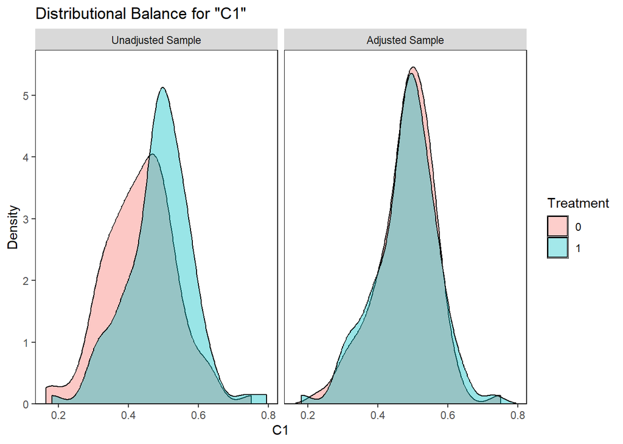

```r
bal.plot(match_cem, "C1", which = "both")
```

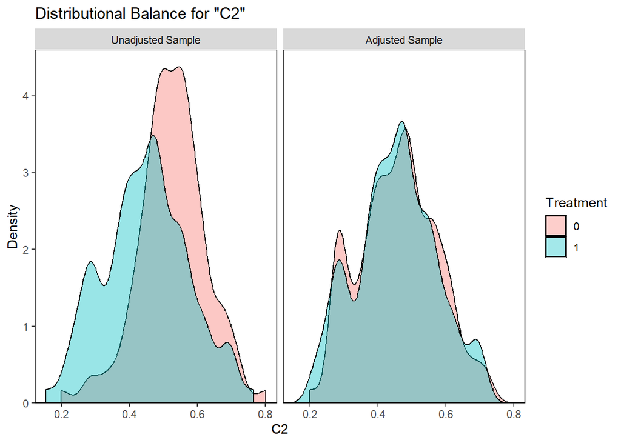

```r
bal.plot(match_cem, "C2", which = "both")
```

Also looks improved.

Outcome model:

```r
outmod <- lm(Y ~ X, data = match_cem_dat, weights = weights)

avg_comparisons(outmod,
                variables = "X",
                vcov = ~subclass,
                newdata = subset(match_cem_dat, X == 1),
                wts = "weights")
```

```
 Term Contrast Estimate Std. Error    z Pr(>|z|)     S 2.5 % 97.5 %
    X    1 - 0     1.18     0.0782 15.1   <0.001 169.8  1.03   1.34

Columns: term, contrast, estimate, std.error, statistic, p.value, s.value, conf.low, conf.high
```

We’re told the true answer is 1 but this estimate is greater than that… what’s going on…? Must be clues back in the original pairs plot.

## Linear regression

Wondering what the ATE looks like from the regression model where the covariates are at their means:

```r
lm(Y ~ X * (scale(C1) + scale(C2)), data = dat) |>
  confint()
```

```
                  2.5 %      97.5 %
(Intercept)  0.06837415  0.16395851
X            1.02715705  1.15921471
scale(C1)   -0.12862230 -0.04184161
scale(C2)    0.07910912  0.18378591
X:scale(C1) -0.01031509  0.11635757
X:scale(C2) -0.24011066 -0.10718878
```

Still over 1.

Try the obvious:

```r
lm(Y ~ X, data = dat) |>
  confint()
```

```
                2.5 %    97.5 %
(Intercept) 0.1345053 0.2267041
X           0.9689097 1.0992986
```

At least the CI includes 1.

Now the covariates:

```r
simp_ols <- lm(Y ~ X + C1 + C2, data = dat)
confint(simp_ols)
```

```
                  2.5 %     97.5 %
(Intercept)  0.08266757  0.5075169
X            1.00121098  1.1409270
C1          -0.79560027 -0.1355159
C2          -0.11888902  0.4533927
```

```r
ncvTest(simp_ols, ~C1)
```

```
Non-constant Variance Score Test
Variance formula: ~ C1
Chisquare = 1.639913, Df = 1, p = 0.20034
```

```r
ncvTest(simp_ols, ~C2)
```

```
Non-constant Variance Score Test
Variance formula: ~ C2
Chisquare = 3.933577, Df = 1, p = 0.047331
```

```r
ncvTest(simp_ols, ~C1 + C2)
```

```
Non-constant Variance Score Test
Variance formula: ~ C1 + C2
Chisquare = 5.190056, Df = 2, p = 0.074644
```

```r
ncvTest(simp_ols)
```

```
Non-constant Variance Score Test
Variance formula: ~ fitted.values
Chisquare = 3.872388, Df = 1, p = 0.049087
```

```r
set.seed(25082023)
Boot(simp_ols, R = 10000) |> confint()
```

```
Bootstrap bca confidence intervals

                  2.5 %     97.5 %
(Intercept)  0.07143161  0.5074293
X            0.99546685  1.1490597
C1          -0.81602320 -0.1659997
C2          -0.17548570  0.5113488
```

Bootstrap CI includes the true answer 1 again… hmmmm!

## Quantile regression

How about fitting a quantile regression model instead, at the median:

```r
rq1 <- rq(Y ~ X + C1 + C2, data = dat, tau = 0.5)
summary(rq1)
```

```
Call: rq(formula = Y ~ X + C1 + C2, tau = 0.5, data = dat)

tau: [1] 0.5

Coefficients:
            coefficients lower bd upper bd
(Intercept)  0.28032      0.05325  0.52443
X            0.98074      0.92415  1.13650
C1          -0.11755     -0.81120  0.15142
C2           0.01144     -0.28228  0.35888
```

That’s also better. Is this a potential clue I wonder… Some genre of skew or heteroskedasticity that’s dragging the estimate above 1…?

## Does fixing any skew help?

```r
set.seed(25082024)
C1_norm <- bestNormalize(dat$C1)
C2_norm <- bestNormalize(dat$C2)
```

```r
C1_norm
```

```
Best Normalizing transformation with 200 Observations
 Estimated Normality Statistics (Pearson P / df, lower => more normal):
 - arcsinh(x): 1.244
 - Box-Cox: 1.258
 - Center+scale: 1.188
 - Double Reversed Log_b(x+a): 1.5321
 - Exp(x): 1.258
 - Log_b(x+a): 1.657
 - orderNorm (ORQ): 1.3945
 - sqrt(x + a): 1.3525
 - Yeo-Johnson: 1.258
Estimation method: Out-of-sample via CV with 10 folds and 5 repeats

Based off these, bestNormalize chose:
center_scale(x) Transformation with 200 nonmissing obs.
 Estimated statistics:
 - mean (before standardization) = 0.4604247
 - sd (before standardization) = 0.1007111
```

```r
C2_norm
```

```
Best Normalizing transformation with 200 Observations
 Estimated Normality Statistics (Pearson P / df, lower => more normal):
 - arcsinh(x): 1.258
 - Box-Cox: 1.083
 - Center+scale: 1.2335
 - Double Reversed Log_b(x+a): 1.303
 - Exp(x): 1.048
 - Log_b(x+a): 1.601
 - orderNorm (ORQ): 1.3035
 - sqrt(x + a): 1.2965
 - Yeo-Johnson: 1.111
Estimation method: Out-of-sample via CV with 10 folds and 5 repeats

Based off these, bestNormalize chose:
Standardized exp(x) Transformation with 200 nonmissing obs.:
 Relevant statistics:
 - mean (before standardization) = 1.638102
 - sd (before standardization) = 0.1924031
```

```r
dat2 <- dat |>
  mutate(C1_t = C1_norm$x.t,
         C2_t = C2_norm$x.t)
```

```r
dat2
```

```
# A tibble: 200 × 6
      C1    C2     X        Y     C1_t    C2_t
   <dbl> <dbl> <dbl>    <dbl>    <dbl>   <dbl>
 1 0.452 0.531     0 -0.00633 -0.0828   0.327
 2 0.491 0.601     0  0.606    0.308    0.965
 3 0.552 0.198     0 -0.358    0.909   -2.18
 4 0.337 0.498     0  0.407   -1.23     0.0369
 5 0.588 0.427     0 -0.190    1.27    -0.549
 6 0.474 0.285     0 -0.518    0.130   -1.60
 7 0.460 0.801     0  0.289   -0.00852  3.06
 8 0.386 0.579     0  0.467   -0.738    0.764
 9 0.615 0.563     0  0.544    1.53     0.610
10 0.499 0.661     0  0.231    0.379    1.55
# ℹ 190 more rows
```

```r
match_cem2 <- matchit(X  ~ C1_t + C2_t,
                     method = "cem",
                     data = dat2,
                     estimand = "ATT")
match_cem_dat2 <- match.data(match_cem2)
```

```r
match_cem2
```

```
A matchit object
 - method: Coarsened exact matching
 - number of obs.: 200 (original), 175 (matched)
 - target estimand: ATT
 - covariates: C1_t, C2_t
```

First look at the ASMD:

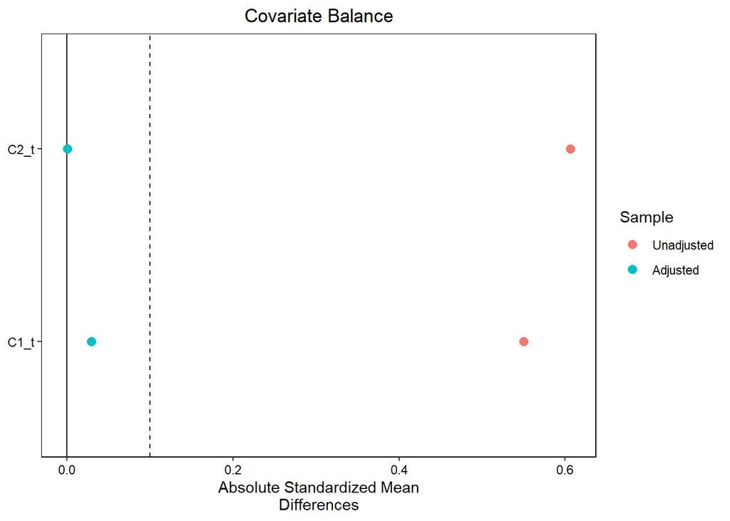

```r
love.plot(match_cem2,
          drop.distance = TRUE,
          var.order = "unadjusted",
          abs = TRUE,
          thresholds = c(m = .1))
```

Matching improved balance.

Density plots:

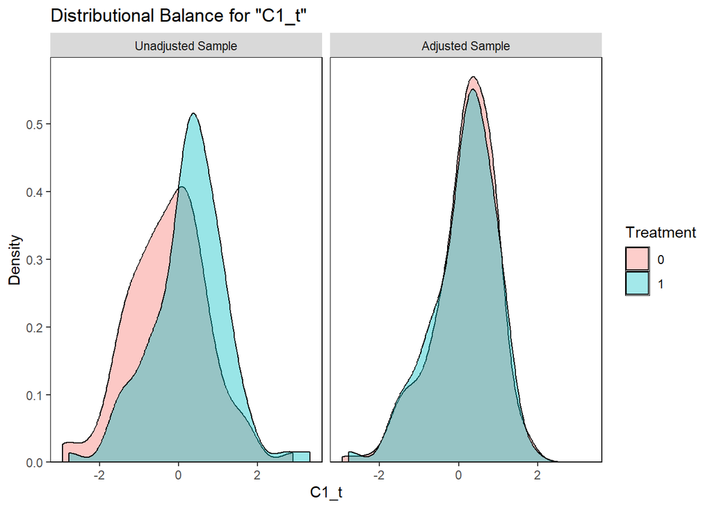

```r
bal.plot(match_cem2, "C1_t", which = "both")
```

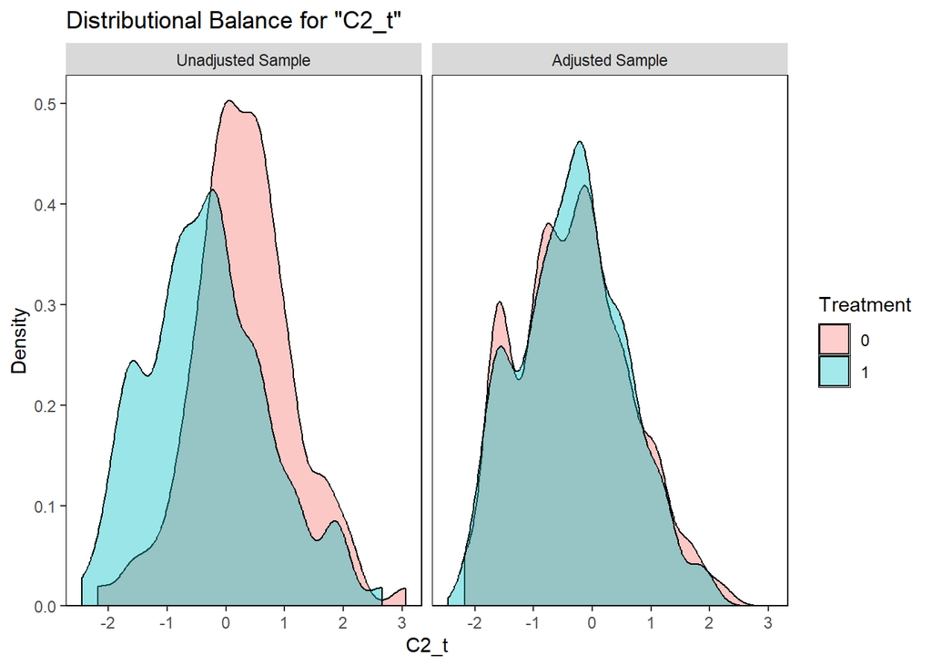

```r
bal.plot(match_cem2, "C2_t", which = "both")
```

```r
outmod2 <- lm(Y ~ X * (C1_t + C2_t), data = match_cem_dat2,
              weights = weights)

avg_comparisons(outmod2,
                variables = "X",
                vcov = ~subclass,
                newdata = subset(match_cem_dat2, X == 1),
                wts = "weights")
```

```
 Term Contrast Estimate Std. Error    z Pr(>|z|)     S 2.5 % 97.5 %
    X    1 - 0      1.2     0.0532 22.6   <0.001 373.3   1.1   1.31

Columns: term, contrast, estimate, std.error, statistic, p.value, s.value, conf.low, conf.high
```

```r
simp_ols2 <- lm(Y ~ X + C1_t + C2_t, data = dat2)
confint(simp_ols2)
```

```
                  2.5 %      97.5 %
(Intercept)  0.11489478  0.20963166
X            1.00100188  1.14057231
C1_t        -0.08067773 -0.01416683
C2_t        -0.01427676  0.05341516
```

Nope.

## How about influential data points?

We need a model. Could start with the simple OLS model, no interactions. We’re primarily interested in anything that significantly shifts the estimate for X.

```r
dat$X_DFBETAS <- dfbetas(simp_ols)[,"X"]
```

We could use Bollen and Jackman’s (1985) threshold:

```r
thresh <- 2/sqrt(nrow(dat))
thresh
```

```
[1] 0.1414214
```

Which points to:

```r
dat |>
  filter(abs(X_DFBETAS) > thresh)
```

```
# A tibble: 13 × 5
      C1    C2     X      Y X_DFBETAS
   <dbl> <dbl> <dbl>  <dbl>     <dbl>
 1 0.552 0.198     0 -0.358     0.302
 2 0.474 0.285     0 -0.518     0.351
 3 0.615 0.563     0  0.544    -0.178
 4 0.542 0.282     0 -0.384     0.287
 5 0.472 0.432     0 -0.301     0.179
 6 0.623 0.494     0 -0.380     0.222
 7 0.506 0.341     0 -0.280     0.204
 8 0.532 0.470     0 -0.230     0.147
 9 0.514 0.410     0 -0.301     0.194
10 0.384 0.495     1  1.63      0.146
11 0.361 0.561     1  1.68      0.193
12 0.556 0.765     1  0.739    -0.266
13 0.406 0.696     1  0.963    -0.192
```

```r
dat_noinf <- dat |>
  filter(abs(X_DFBETAS) <= thresh)
```

Let’s try again with CEM:

```r
match_cem_noinf <- matchit(X  ~ C1 + C2,
                     method = "cem",
                     data = dat_noinf,
                     estimand = "ATT")
match_cem_dat_noinf <- match.data(match_cem_noinf)
```

```r
match_cem_noinf
```

```
A matchit object
 - method: Coarsened exact matching
 - number of obs.: 187 (original), 150 (matched)
 - target estimand: ATT
 - covariates: C1, C2
```

First look at the ASMD:

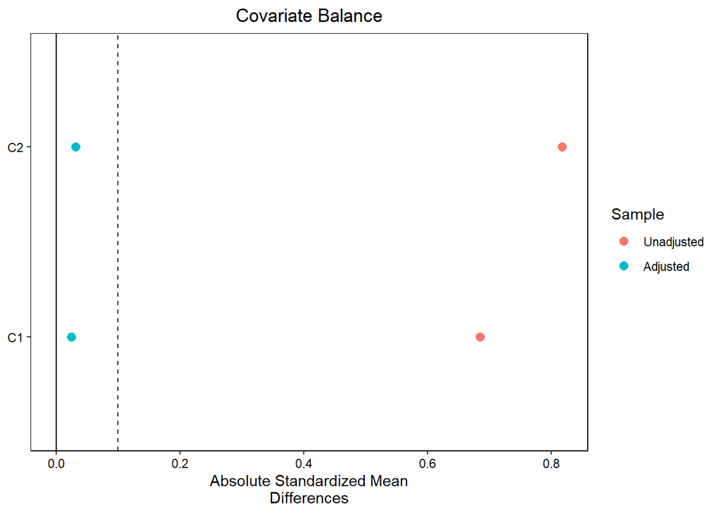

```r
love.plot(match_cem_noinf,
          drop.distance = TRUE,
          var.order = "unadjusted",
          abs = TRUE,
          thresholds = c(m = .1))
```

Matching improved balance.

Density plots:

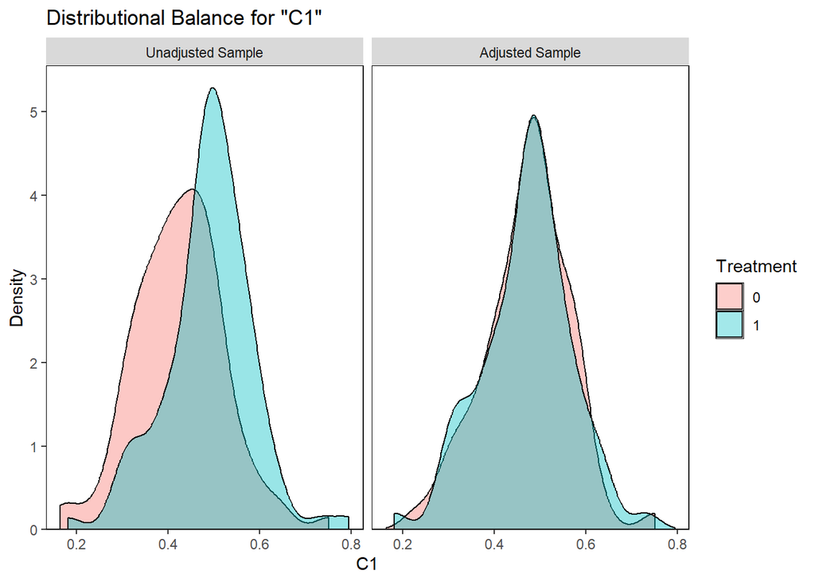

```r
bal.plot(match_cem_noinf, "C1", which = "both")
```

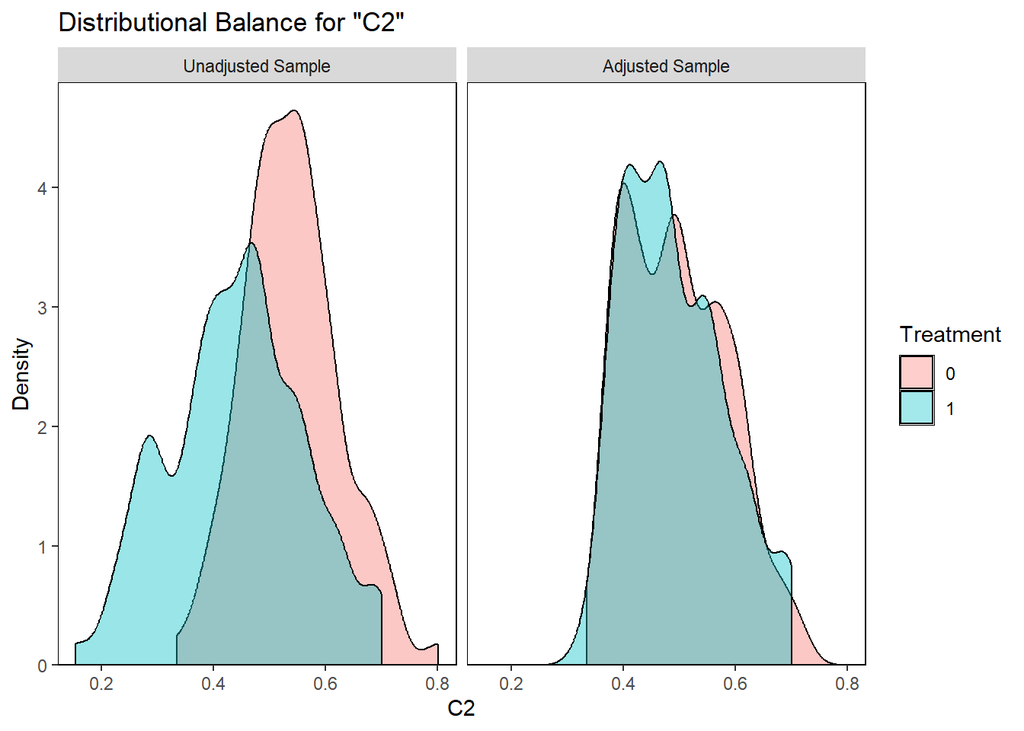

```r
bal.plot(match_cem_noinf, "C2", which = "both")
```

Also still looks improved.

Outcome model:

```r
outmod_noinf <- lm(Y ~ X, data = match_cem_dat_noinf, weights = weights)

avg_comparisons(outmod_noinf,
                variables = "X",
                vcov = ~subclass,
                newdata = subset(match_cem_dat_noinf, X == 1),
                wts = "weights")
```

```
 Term Contrast Estimate Std. Error    z Pr(>|z|)     S 2.5 % 97.5 %
    X    1 - 0        1     0.0453 22.2   <0.001 359.4 0.915   1.09

Columns: term, contrast, estimate, std.error, statistic, p.value, s.value, conf.low, conf.high
```

OMG look at that estimate – exactly 1! Excitement tempered somewhat by the fact that I’ve analysed this poor n=200 simulated dataset to within an inch of its existence. Really need to replicate the approach on (ideally) a large number of other similar datasets.

Also this feels naughty, since I’ve used OLS, pruned out observations that were influential, relative to the model I used, and then threw that at CEM. It’s the reverse of what we usually want to do, i.e., use CEM as a non-parametric preprocessing step before applying a parametric model to estimate outcomes.

So now I’m wondering if DFBETAS is already defined for matching. It wouldn’t be hard to do it but it’ll be inefficient for large datasets:

1. Match.
2. Estimate outcomes model.
3. Leave each observation out in turn, reapply CEM, refit the outcomes model, and calculate DFBETAS, which is simply the shift in the coefficient for X divided by its SE.
4. Since the sample size for each run of step 3 is likely to vary, we need to choose a constant for the threshold indicating an influential observation. Maybe just the total sample going in.

Alternatively, and easier, we could just match once and calculate DFBETAS for the outcome model. Let’s try…

First revisit the original match:

```r
match_cem
```

```
A matchit object
 - method: Coarsened exact matching
 - number of obs.: 200 (original), 190 (matched)
 - target estimand: ATT
 - covariates: C1, C2
```

This was the outcomes model, without robust SE, but it’ll do…:

```r
summary(outmod)
```

```
Call:
lm(formula = Y ~ X, data = match_cem_dat, weights = weights)

Weighted Residuals:
     Min       1Q   Median       3Q      Max
-1.46342 -0.09702  0.05701  0.18385  1.00423

Coefficients:
            Estimate Std. Error t value Pr(>|t|)
(Intercept)  0.03491    0.02783   1.254    0.211
X            1.18384    0.03936  30.078   <2e-16 ***
---
Signif. codes:  0 '***' 0.001 '**' 0.01 '*' 0.05 '.' 0.1 ' ' 1

Residual standard error: 0.2713 on 188 degrees of freedom
Multiple R-squared:  0.8279,    Adjusted R-squared:  0.827
F-statistic: 904.7 on 1 and 188 DF,  p-value: < 2.2e-16
```

Add in the DFBETAS estimates:

```r
match_cem_dat$X_DFBETAS <- dfbetas(outmod)[,"X"]
```

```r
new_thresh <- 2/sqrt(nrow(match_cem_dat))
new_thresh
```

```
[1] 0.1450953
```

```r
match_cem_dat_noinf <- match_cem_dat |>
  filter(abs(X_DFBETAS) <= new_thresh) |>
  select(-c(weights, subclass))
match_cem_dat_noinf
```

```
# A tibble: 180 × 5
      C1    C2     X        Y X_DFBETAS
   <dbl> <dbl> <dbl>    <dbl>     <dbl>
 1 0.452 0.531     0 -0.00633   0.00402
 2 0.491 0.601     0  0.606    -0.0927
 3 0.552 0.198     0 -0.358     0.106
 4 0.337 0.498     0  0.407    -0.0110
 5 0.386 0.579     0  0.467    -0.0356
 6 0.615 0.563     0  0.544    -0.139
 7 0.499 0.661     0  0.231    -0.0263
 8 0.526 0.674     0  0.154    -0.00798
 9 0.397 0.583     0  0.305    -0.0223
10 0.510 0.565     0  0.251    -0.0210
# ℹ 170 more rows
```

Ten observations have been dropped off:

```r
nrow(match_cem_dat_noinf)
```

```
[1] 180
```

Now, go again (really should have wrapped this all in a function!):

```r
match_cem3 <- matchit(X  ~ C1 + C2,
                     method = "cem",
                     data = match_cem_dat_noinf,
                     estimand = "ATT")
match_cem_dat3 <- match.data(match_cem3)
```

```r
match_cem3
```

```
A matchit object
 - method: Coarsened exact matching
 - number of obs.: 180 (original), 135 (matched)
 - target estimand: ATT
 - covariates: C1, C2
```

Look at the ASMD:

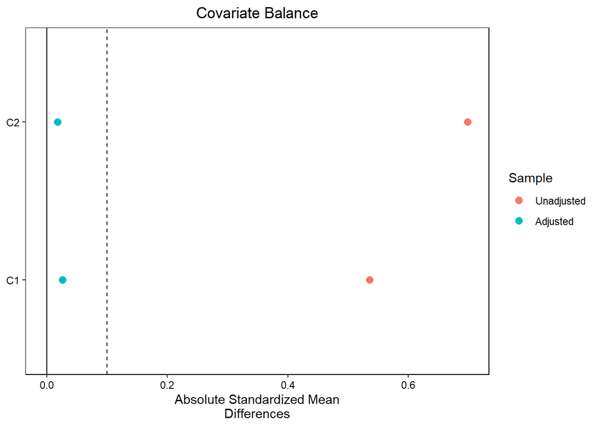

```r
love.plot(match_cem3,
          drop.distance = TRUE,
          var.order = "unadjusted",
          abs = TRUE,
          thresholds = c(m = .1))
```

Matching (still) improved balance.

Density plots:

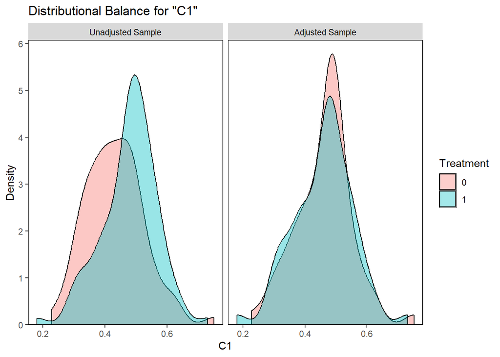

```r
bal.plot(match_cem3, "C1", which = "both")
```

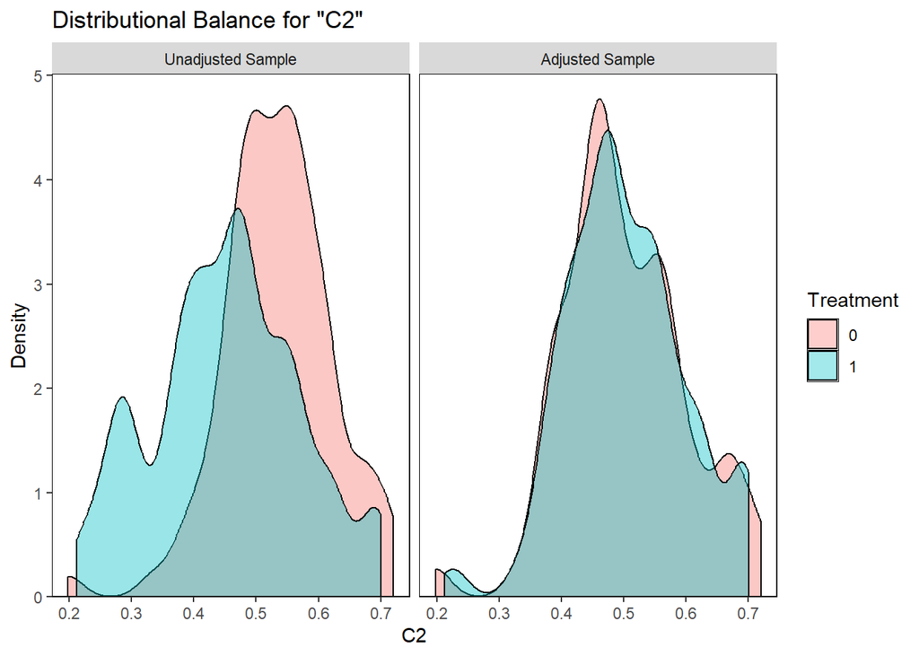

```r
bal.plot(match_cem3, "C2", which = "both")
```

Okay C2 looks a bit wilder?

```r
outmod3 <- lm(Y ~ X, data = match_cem_dat3, weights = weights)

avg_comparisons(outmod3,
                variables = "X",
                vcov = ~subclass,
                newdata = subset(match_cem_dat3, X == 1),
                wts = "weights")
```

```
 Term Contrast Estimate Std. Error    z Pr(>|z|)     S 2.5 % 97.5 %
    X    1 - 0    0.981     0.0454 21.6   <0.001 341.8 0.892   1.07

Columns: term, contrast, estimate, std.error, statistic, p.value, s.value, conf.low, conf.high
```

Now the estimates is lower than 1 and the CI straddles 1.

Finally, try a doubly robust estimate:

```r
outmod3_dr <- lm(Y ~ X * (C1 + C2),
                 data = match_cem_dat3,
                 weights = weights)

avg_comparisons(outmod3_dr,
                variables = "X",
                vcov = ~subclass,
                newdata = subset(match_cem_dat3, X == 1),
                wts = "weights")
```

```
 Term Contrast Estimate Std. Error    z Pr(>|z|)     S 2.5 % 97.5 %
    X    1 - 0    0.977      0.047 20.8   <0.001 316.6 0.885   1.07

Columns: term, contrast, estimate, std.error, statistic, p.value, s.value, conf.low, conf.high
```

Even smaller estimate, but CI still includes 1.

## Overlap weights

I haven’t touched propensity score methods yet.

If there’s something funny going on with extreme values then we might expect overlap weights to be unbothered by them. However, they give us a different estimand: average treatment effect at overlap (ATO).

Let’s see what happens; back to the original data:

```r
dat_weight <- weightit(X ~ C1 + C2,
              method = "glm",
              estimand = "ATO",
              data = dat)
dat_weight
```

```
A weightit object
 - method: "glm" (propensity score weighting with GLM)
 - number of obs.: 200
 - sampling weights: none
 - treatment: 2-category
 - estimand: ATO
 - covariates: C1, C2
```

```r
dat$OW <- dat_weight$weights
```

First, without any covariates in the outcome model:

```r
outmod_ato <- lm(Y ~ X, data = dat, weights = OW)

avg_comparisons(outmod_ato,
                variables = "X",
                vcov = "HC3",
                wts = "OW")
```

```
 Term Contrast Estimate Std. Error    z Pr(>|z|)     S 2.5 % 97.5 %
    X    1 - 0     1.08      0.041 26.2   <0.001 500.8 0.995   1.16

Columns: term, contrast, estimate, std.error, statistic, p.value, s.value, conf.low, conf.high
```

The CI just about includes 1.

If we make it doubly-robust, though, then it breaks:

```r
outmod_ato_dr <- lm(Y ~ X * (C1 + C2), data = dat, weights = OW)

avg_comparisons(outmod_ato_dr,
                variables = "X",
                vcov = "HC3",
                wts = "OW")
```

```
 Term Contrast Estimate Std. Error    z Pr(>|z|)     S 2.5 % 97.5 %
    X    1 - 0     1.08     0.0339 31.7   <0.001 731.8  1.01   1.14

Columns: term, contrast, estimate, std.error, statistic, p.value, s.value, conf.low, conf.high
```

CI just excludes 1.